# Kaggle Competition

## Data Preprocessing

```python
import pandas as pd
import numpy as np
```

### Read Files

```python
data_id = pd.read_csv('data_identification.csv')
data_id.shape
```

```
(1867535, 2)
```

```python
emotion = pd.read_csv('emotion.csv')
emotion.shape
```

```
(1455563, 2)
```

```python
import json
```

```python
tweets = []

with open('tweets_DM.json', 'r') as file:
    for line in file:
        tweet = json.loads(line)
        tweets.append(tweet)
```

```python
tweets_df = pd.DataFrame(tweets)
source_data = pd.json_normalize(tweets_df['_source'])
tweets_df = tweets_df.drop('_source', axis=1).join(source_data)
tweets_df.rename(columns={'tweet.tweet_id': 'tweet_id', 'tweet.hashtags': 'hashtags'}, inplace=True)
tweets_df
```

|  | _score | _index | _crawldate | _type | hashtags | tweet_id | tweet.text |
| --- | --- | --- | --- | --- | --- | --- | --- |
| 0 | 391 | hashtag_tweets | 2015-05-23 11:42:47 | tweets | [Snapchat] | 0x376b20 | People who post "add me on #Snapchat" must be ... |
| 1 | 433 | hashtag_tweets | 2016-01-28 04:52:09 | tweets | [freepress, TrumpLegacy, CNN] | 0x2d5350 | @brianklaas As we see, Trump is dangerous to #... |
| 2 | 232 | hashtag_tweets | 2017-12-25 04:39:20 | tweets | [bibleverse] | 0x28b412 | Confident of your obedience, I write to you, k... |
| 3 | 376 | hashtag_tweets | 2016-01-24 23:53:05 | tweets | [] | 0x1cd5b0 | Now ISSA is stalking Tasha 😂😂😂 <LH> |
| 4 | 989 | hashtag_tweets | 2016-01-08 17:18:59 | tweets | [] | 0x2de201 | "Trust is not the same as faith. A friend is s... |
| ... | ... | ... | ... | ... | ... | ... | ... |
| 1867530 | 827 | hashtag_tweets | 2015-05-12 12:51:52 | tweets | [mixedfeeling, butimTHATperson] | 0x316b80 | When you buy the last 2 tickets remaining for ... |
| 1867531 | 368 | hashtag_tweets | 2017-10-02 17:54:04 | tweets | [] | 0x29d0cb | I swear all this hard work gone pay off one da... |
| 1867532 | 498 | hashtag_tweets | 2016-10-10 11:04:32 | tweets | [] | 0x2a6a4f | @Parcel2Go no card left when I wasn't in so I ... |
| 1867533 | 840 | hashtag_tweets | 2016-09-02 14:25:06 | tweets | [] | 0x24faed | Ah, corporate life, where you can date <LH> us... |
| 1867534 | 360 | hashtag_tweets | 2016-11-16 01:40:07 | tweets | [Sundayvibes] | 0x34be8c | Blessed to be living #Sundayvibes <LH> |

1867535 rows × 7 columns

### Clean the Data Set

```python
tweets_df['_index'].unique()
```

```
array(['hashtag_tweets'], dtype=object)
```

```python
tweets_df['_type'].unique()
```

```
array(['tweets'], dtype=object)
```

since the `_index`, `_type`, and the `_crawldate` columns does not provide useful information for understanding the emotion of the text, we can drop them

```python
tweets_df = tweets_df.drop(columns=['_index', '_crawldate', '_type', '_score'])
tweets_df
```

|  | hashtags | tweet_id | tweet.text |
| --- | --- | --- | --- |
| 0 | [Snapchat] | 0x376b20 | People who post "add me on #Snapchat" must be ... |
| 1 | [freepress, TrumpLegacy, CNN] | 0x2d5350 | @brianklaas As we see, Trump is dangerous to #... |
| 2 | [bibleverse] | 0x28b412 | Confident of your obedience, I write to you, k... |
| 3 | [] | 0x1cd5b0 | Now ISSA is stalking Tasha 😂😂😂 <LH> |
| 4 | [] | 0x2de201 | "Trust is not the same as faith. A friend is s... |
| ... | ... | ... | ... |
| 1867530 | [mixedfeeling, butimTHATperson] | 0x316b80 | When you buy the last 2 tickets remaining for ... |
| 1867531 | [] | 0x29d0cb | I swear all this hard work gone pay off one da... |
| 1867532 | [] | 0x2a6a4f | @Parcel2Go no card left when I wasn't in so I ... |
| 1867533 | [] | 0x24faed | Ah, corporate life, where you can date <LH> us... |
| 1867534 | [Sundayvibes] | 0x34be8c | Blessed to be living #Sundayvibes <LH> |

1867535 rows × 3 columns

then combine the labels of emotion and tweet identification to the data frame

```python
merged_df = pd.merge(tweets_df, emotion, on='tweet_id', how='left')
merged_df = pd.merge(merged_df, data_id, on='tweet_id', how='left')
merged_df
```

|  | hashtags | tweet_id | tweet.text | emotion | identification |
| --- | --- | --- | --- | --- | --- |
| 0 | [Snapchat] | 0x376b20 | People who post "add me on #Snapchat" must be ... | anticipation | train |
| 1 | [freepress, TrumpLegacy, CNN] | 0x2d5350 | @brianklaas As we see, Trump is dangerous to #... | sadness | train |
| 2 | [bibleverse] | 0x28b412 | Confident of your obedience, I write to you, k... | NaN | test |
| 3 | [] | 0x1cd5b0 | Now ISSA is stalking Tasha 😂😂😂 <LH> | fear | train |
| 4 | [] | 0x2de201 | "Trust is not the same as faith. A friend is s... | NaN | test |
| ... | ... | ... | ... | ... | ... |
| 1867530 | [mixedfeeling, butimTHATperson] | 0x316b80 | When you buy the last 2 tickets remaining for ... | NaN | test |
| 1867531 | [] | 0x29d0cb | I swear all this hard work gone pay off one da... | NaN | test |
| 1867532 | [] | 0x2a6a4f | @Parcel2Go no card left when I wasn't in so I ... | NaN | test |
| 1867533 | [] | 0x24faed | Ah, corporate life, where you can date <LH> us... | joy | train |
| 1867534 | [Sundayvibes] | 0x34be8c | Blessed to be living #Sundayvibes <LH> | joy | train |

1867535 rows × 5 columns

```python
print(merged_df.isnull().sum())

# the testing emotions are not given
```

```
hashtags               0
tweet_id               0
tweet.text             0
emotion           411972
identification         0
dtype: int64
```

to process the text part, some first-step cleaning was done to the data including removing html tags, mentions (any @____), hashtag in the text, urls, characters and numbers

```python
import re

def clean_text(text):
    text = re.sub(r'<[^>]+>', '', text)  # Remove HTML tags
    text = re.sub(r'@\w+', '', text)  # Remove mentions
    text = text.replace('#', '') # Remove hashtags
    text = re.sub(r'http\S+', '', text)  # Remove URLs
    text = re.sub(r'[^A-Za-z0-9\s]', '', text)  # Remove special chars
    text = re.sub(r'\d+', '', text) # Remove numbers
    text = text.strip()
    text = text.lower()
    return text
```

```python
merged_df['text'] = merged_df['tweet.text'].apply(clean_text)
```

```python
tweets_cleaned = merged_df.drop('tweet.text', axis=1)
tweets_cleaned
```

|  | hashtags | tweet_id | emotion | identification | text |
| --- | --- | --- | --- | --- | --- |
| 0 | [Snapchat] | 0x376b20 | anticipation | train | people who post add me on snapchat must be deh... |
| 1 | [freepress, TrumpLegacy, CNN] | 0x2d5350 | sadness | train | as we see trump is dangerous to freepress arou... |
| 2 | [bibleverse] | 0x28b412 | NaN | test | confident of your obedience i write to you kno... |
| 3 | [] | 0x1cd5b0 | fear | train | now issa is stalking tasha |
| 4 | [] | 0x2de201 | NaN | test | trust is not the same as faith a friend is som... |
| ... | ... | ... | ... | ... | ... |
| 1867530 | [mixedfeeling, butimTHATperson] | 0x316b80 | NaN | test | when you buy the last tickets remaining for a... |
| 1867531 | [] | 0x29d0cb | NaN | test | i swear all this hard work gone pay off one day |
| 1867532 | [] | 0x2a6a4f | NaN | test | no card left when i wasnt in so i have no idea... |
| 1867533 | [] | 0x24faed | joy | train | ah corporate life where you can date using ju... |
| 1867534 | [Sundayvibes] | 0x34be8c | joy | train | blessed to be living sundayvibes |

1867535 rows × 5 columns

```python
for i in range(10):
    print(f"Tweet {i+1}: {merged_df['tweet.text'].iloc[i]}\n")
    print(f"Tweet {i+1}: {tweets_cleaned['text'].iloc[i]}\n")
```

```
Tweet 1: People who post "add me on #Snapchat" must be dehydrated. Cuz man.... that's <LH>

Tweet 1: people who post add me on snapchat must be dehydrated cuz man thats

Tweet 2: @brianklaas As we see, Trump is dangerous to #freepress around the world. What a <LH> <LH> #TrumpLegacy.  #CNN

Tweet 2: as we see trump is dangerous to freepress around the world what a   trumplegacy  cnn

Tweet 3: Confident of your obedience, I write to you, knowing that you will do even more than I ask. (Philemon 1:21) 3/4 #bibleverse <LH> <LH>

Tweet 3: confident of your obedience i write to you knowing that you will do even more than i ask philemon   bibleverse

Tweet 4: Now ISSA is stalking Tasha 😂😂😂 <LH>

Tweet 4: now issa is stalking tasha

Tweet 5: "Trust is not the same as faith. A friend is someone you trust. Putting faith in anyone is a mistake." ~ Christopher Hitchens <LH> <LH>

Tweet 5: trust is not the same as faith a friend is someone you trust putting faith in anyone is a mistake  christopher hitchens

Tweet 6: @RISKshow @TheKevinAllison Thx for the BEST TIME tonight. What stories! Heartbreakingly <LH> #authentic #LaughOutLoud good!!

Tweet 6: thx for the best time tonight what stories heartbreakingly  authentic laughoutloud good

Tweet 7: Still waiting on those supplies Liscus. <LH>

Tweet 7: still waiting on those supplies liscus

Tweet 8: Love knows no gender. 😢😭 <LH>

Tweet 8: love knows no gender

Tweet 9: @DStvNgCare @DStvNg More highlights are being shown than actual sports! Who watches triathlon highlights anyway? <LH> #LeagueCup

Tweet 9: more highlights are being shown than actual sports who watches triathlon highlights anyway  leaguecup

Tweet 10: When do you have enough ? When are you satisfied ? Is you goal really all about money ?  #materialism #money #possessions <LH>

Tweet 10: when do you have enough  when are you satisfied  is you goal really all about money   materialism money possessions
```

## Exploratory Data Analysis (EDA)

this part will include some data visualizations and frequency analysis of the text data

```python
import seaborn as sns
import matplotlib.pyplot as plt
import nltk
```

### Basic Structure

```python
tweets_cleaned.info()
```

```
<class 'pandas.core.frame.DataFrame'>
RangeIndex: 1867535 entries, 0 to 1867534
Data columns (total 5 columns):
 #   Column          Dtype
---  ------          -----
 0   hashtags        object
 1   tweet_id        object
 2   emotion         object
 3   identification  object
 4   text            object
dtypes: object(5)
memory usage: 71.2+ MB
```

### Distribution of Emotions

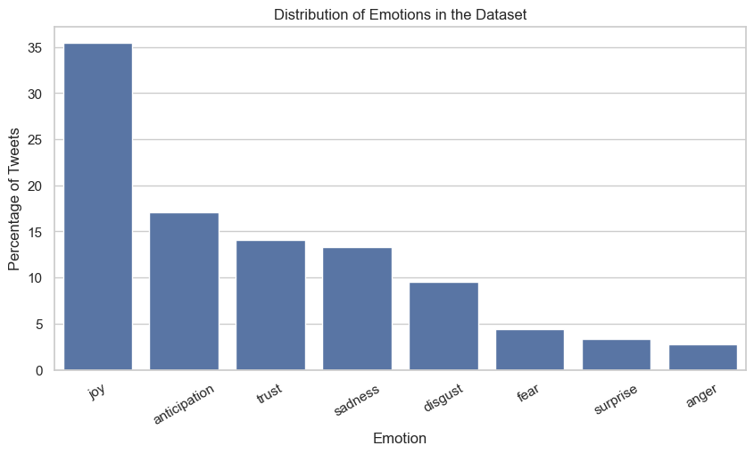

```python
emotion_counts = tweets_cleaned['emotion'].value_counts(normalize=True) * 100
sns.set(style="whitegrid")
plt.figure(figsize=(10, 5))
sns.barplot(x=emotion_counts.index, y=emotion_counts.values)
plt.title('Distribution of Emotions in the Dataset')
plt.ylabel('Percentage of Tweets')
plt.xlabel('Emotion')
plt.xticks(rotation=30)
plt.show()
```

- distribution of the data set is inbalanced can lead to
  - model bias: the model may become biased towards the more frequent classes. This is because there is more data for the model to learn from for these classes, leading to better performance on them compared to the less frequent classes
  - poor generalization: may not generalize well to new, unseen data, especially for the underrepresented classes

### Word Frequency Analysis

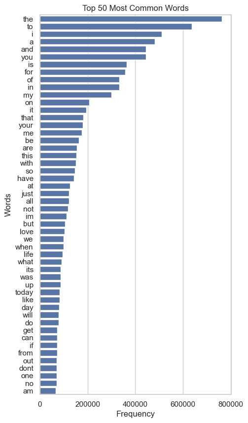

```python
from collections import Counter

topNwords = 50
words = ' '.join(tweets_cleaned['text']).split()
word_freq = Counter(words)
most_common_words = word_freq.most_common(topNwords)

plt.figure(figsize=(5, 10))
sns.barplot(x=[val[1] for val in most_common_words], y=[val[0] for val in most_common_words])
plt.title(f'Top {topNwords} Most Common Words')
plt.xlabel('Frequency')
plt.ylabel('Words')
plt.show()
```

- it is discovered that these top words are not very benefitial for emotion classification
- decided to remove stop words first

```python
from nltk.corpus import stopwords

nltk.download('stopwords')
stop = set(stopwords.words('english'))

tweets_cleaned['text'] = tweets_cleaned['text'].apply(lambda x: ' '.join([word for word in x.split() if word not in (stop)]))
```

```python
from nltk.stem import WordNetLemmatizer
from nltk.tokenize import word_tokenize

nltk.download('wordnet')
nltk.download('punkt')

lemmatizer = WordNetLemmatizer()

def lemmatize_text(text):
    return ' '.join([lemmatizer.lemmatize(word) for word in word_tokenize(text)])

tweets_cleaned['text'] = tweets_cleaned['text'].apply(lemmatize_text)
```

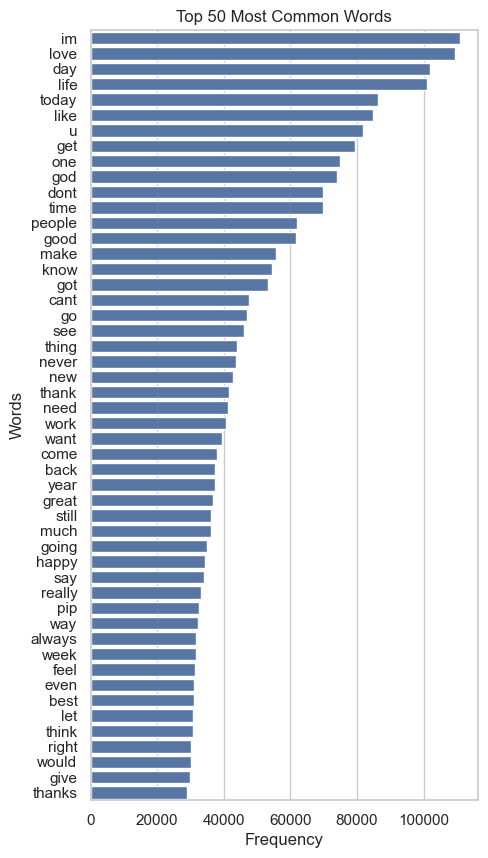

```python
topNwords = 50
words = ' '.join(tweets_cleaned['text']).split()
word_freq = Counter(words)
most_common_words = word_freq.most_common(topNwords)

plt.figure(figsize=(5, 10))
sns.barplot(x=[val[1] for val in most_common_words], y=[val[0] for val in most_common_words])
plt.title(f'Top {topNwords} Most Common Words')
plt.xlabel('Frequency')
plt.ylabel('Words')
plt.show()
```

- high frequency words now turned into more meaningful words

```python
unique_emotions = tweets_cleaned['emotion'].unique()
emotion_specific_words = {}

for emotion in unique_emotions:
    specific_tweets = tweets_cleaned[tweets_cleaned['emotion'] == emotion]['text']
    word_freq = Counter(' '.join(specific_tweets).split())
    emotion_specific_words[emotion] = word_freq.most_common(5)

for emotion, common_words in emotion_specific_words.items():
    print(f"Emotion: {emotion}, Common words: {common_words}")
```

```
Emotion: anticipation, Common words: [('life', 32647), ('god', 29806), ('dream', 16431), ('u', 14663), ('come', 12479)]
Emotion: sadness, Common words: [('im', 10928), ('like', 10198), ('sad', 8758), ('please', 8698), ('dont', 8486)]
Emotion: nan, Common words: []
Emotion: fear, Common words: [('im', 5028), ('issa', 3402), ('lawrence', 3278), ('like', 3160), ('get', 2880)]
Emotion: joy, Common words: [('love', 58525), ('today', 36218), ('day', 33856), ('pip', 32376), ('life', 29614)]
Emotion: anger, Common words: [('im', 3282), ('get', 2819), ('dont', 2097), ('like', 1964), ('people', 1865)]
Emotion: trust, Common words: [('day', 16214), ('today', 13754), ('im', 13419), ('life', 12256), ('love', 9308)]
Emotion: disgust, Common words: [('like', 8583), ('u', 6879), ('get', 6470), ('im', 6455), ('people', 6428)]
Emotion: surprise, Common words: [('im', 2872), ('like', 2577), ('get', 1999), ('dont', 1980), ('people', 1738)]
```

## Model Training

```python
train_data = tweets_cleaned[tweets_cleaned['identification'] == 'train']
test_data = tweets_cleaned[tweets_cleaned['identification'] == 'test']
```

```python
train_data
```

|  | hashtags | tweet_id | emotion | identification | text |
| --- | --- | --- | --- | --- | --- |
| 0 | [Snapchat] | 0x376b20 | anticipation | train | people post add snapchat must dehydrated cuz m... |
| 1 | [freepress, TrumpLegacy, CNN] | 0x2d5350 | sadness | train | see trump dangerous freepress around world tru... |
| 3 | [] | 0x1cd5b0 | fear | train | issa stalking tasha |
| 5 | [authentic, LaughOutLoud] | 0x1d755c | joy | train | thx best time tonight story heartbreakingly au... |
| 6 | [] | 0x2c91a8 | anticipation | train | still waiting supply liscus |
| ... | ... | ... | ... | ... | ... |
| 1867526 | [NoWonder, Happy] | 0x321566 | joy | train | im happy nowonder name show happy |
| 1867527 | [] | 0x38959e | joy | train | every circumtance id like thankful almighty je... |
| 1867528 | [blessyou] | 0x2cbca6 | joy | train | there currently two girl walking around librar... |
| 1867533 | [] | 0x24faed | joy | train | ah corporate life date using relative anachron... |
| 1867534 | [Sundayvibes] | 0x34be8c | joy | train | blessed living sundayvibes |

1455563 rows × 5 columns

```python
test_data
```

|  | hashtags | tweet_id | emotion | identification | text |
| --- | --- | --- | --- | --- | --- |
| 2 | [bibleverse] | 0x28b412 | NaN | test | confident obedience write knowing even ask phi... |
| 4 | [] | 0x2de201 | NaN | test | trust faith friend someone trust putting faith... |
| 9 | [materialism, money, possessions] | 0x218443 | NaN | test | enough satisfied goal really money materialism... |
| 30 | [GodsPlan, GodsWork] | 0x2939d5 | NaN | test | god woke chase day godsplan godswork |
| 33 | [] | 0x26289a | NaN | test | tough time turn symbol hope |
| ... | ... | ... | ... | ... | ... |
| 1867525 | [] | 0x2913b4 | NaN | test | message ye heard beginning love one another jo... |
| 1867529 | [] | 0x2a980e | NaN | test | lad hath five barley loaf two small fish among... |
| 1867530 | [mixedfeeling, butimTHATperson] | 0x316b80 | NaN | test | buy last ticket remaining show sell mixedfeeli... |
| 1867531 | [] | 0x29d0cb | NaN | test | swear hard work gone pay one day |
| 1867532 | [] | 0x2a6a4f | NaN | test | card left wasnt idea get parcel |

411972 rows × 5 columns

```python
train_data = train_data.drop('identification', axis=1)
test_data = test_data.drop('identification', axis=1)
```

```python
X_data = train_data.drop('emotion', axis=1)
y_data = train_data['emotion']
X_valid = test_data.drop('emotion', axis=1)
```

```python
y_submit = pd.DataFrame({
    'id': X_valid['tweet_id'],
    'emotion': test_data['emotion']
})

y_submit
```

|  | id | emotion |
| --- | --- | --- |
| 2 | 0x28b412 | NaN |
| 4 | 0x2de201 | NaN |
| 9 | 0x218443 | NaN |
| 30 | 0x2939d5 | NaN |
| 33 | 0x26289a | NaN |
| ... | ... | ... |
| 1867525 | 0x2913b4 | NaN |
| 1867529 | 0x2a980e | NaN |
| 1867530 | 0x316b80 | NaN |
| 1867531 | 0x29d0cb | NaN |
| 1867532 | 0x2a6a4f | NaN |

411972 rows × 2 columns

change labels to one-hot encoding

```python
from sklearn.preprocessing import LabelEncoder
import keras
from keras.utils import to_categorical

label_encoder = LabelEncoder()
y_encoded = label_encoder.fit_transform(y_data)
y_one_hot = to_categorical(y_encoded)
```

```python
from sklearn.model_selection import train_test_split

# Assuming 'data' is your padded sequences and 'your_labels' are your labels
X_train, X_test, y_train, y_test = train_test_split(X_data, y_one_hot, test_size=0.2, random_state=42)
```

```python
from gensim.models import KeyedVectors

# Load the model (this will take some time)
google_w2v_model = KeyedVectors.load_word2vec_format('GoogleNews-vectors-negative300.bin.gz', binary=True)
```

tokenize the word vecotors and make them into sequences based on the Google model

```python
from keras.preprocessing.text import Tokenizer
from keras.preprocessing.sequence import pad_sequences

tokenizer = Tokenizer()
tokenizer.fit_on_texts(X_train['text'])
sequences = tokenizer.texts_to_sequences(X_train['text'])
```

```python
tokenizer2 = Tokenizer()
tokenizer2.fit_on_texts(X_train['text'])
sequences2 = tokenizer2.texts_to_sequences(X_test['text'])
```

```python
tokenizer3 = Tokenizer()
tokenizer3.fit_on_texts(X_valid['text'])
sequences3 = tokenizer3.texts_to_sequences(X_valid['text'])
```

padded the sequences to have uniform length, the max length is set to 50

```python
# Pad sequences to ensure uniform length
max_length = 50
X_train_padded = pad_sequences(sequences, maxlen=max_length)
X_test_padded = pad_sequences(sequences2, maxlen=max_length)
X_valid_padded = pad_sequences(sequences3, maxlen=max_length)
```

```python
vocab_size = len(tokenizer.word_index) + 1
embedding_matrix = np.zeros((vocab_size, 300))  # 300 is the dimensionality of GoogleNews vectors

for word, i in tokenizer.word_index.items():
    if word in google_w2v_model:
        embedding_matrix[i] = google_w2v_model[word]
```

```python
from keras.models import Sequential
from keras.layers import Embedding, LSTM, Dense

model = Sequential()
model.add(Embedding(vocab_size, 300,
                    weights=[embedding_matrix],
                    input_length=max_length,
                    trainable=False))
model.add(LSTM(100))
model.add(Dense(8, activation='softmax'))

model.compile(loss='categorical_crossentropy',
              optimizer='adam',
              metrics=['accuracy'])
```

[output not shown]

```python
num_epochs = 10
batch_size = 25

model.fit(X_train_padded, y_train, epochs=num_epochs, batch_size=batch_size, validation_split=0.1)
```

```
2023-12-31 02:13:35.086088: I tensorflow/core/grappler/optimizers/custom_graph_optimizer_registry.cc:117] Plugin optimizer for device_type GPU is enabled.
```

```
<keras.src.callbacks.History at 0x61634a0b0>
```

```python
loss, accuracy = model.evaluate(X_test_padded, y_test)
print(f'Test Accuracy: {accuracy*100:.2f}%')
```

```
Test Accuracy: 52.17%
```

```python
predictions = model.predict(X_valid_padded)
```

```python
predictions
```

```
array([[0.0313473 , 0.13781048, 0.14356543, ..., 0.20847818, 0.00858407,
        0.0355196 ],
       [0.01138101, 0.04839285, 0.07681911, ..., 0.2734959 , 0.08086084,
        0.04380331],
       [0.00664917, 0.1746202 , 0.0410641 , ..., 0.10083697, 0.03518936,
        0.13484192],
       ...,
       [0.00288988, 0.30807176, 0.01014552, ..., 0.00520783, 0.01221734,
        0.40342933],
       [0.0077603 , 0.05795806, 0.01774925, ..., 0.04405299, 0.01190932,
        0.1304694 ],
       [0.00503109, 0.33500794, 0.14155719, ..., 0.11989159, 0.04174703,
        0.09989318]], dtype=float32)
```

```python
class_indices = np.argmax(predictions, axis=1)
original_classes = label_encoder.inverse_transform(class_indices)
```

```python
y_submit['emotion'] = original_classes
```

```python
y_submit
```

|  | id | emotion |
| --- | --- | --- |
| 2 | 0x28b412 | joy |
| 4 | 0x2de201 | joy |
| 9 | 0x218443 | joy |
| 30 | 0x2939d5 | sadness |
| 33 | 0x26289a | fear |
| ... | ... | ... |
| 1867525 | 0x2913b4 | joy |
| 1867529 | 0x2a980e | joy |
| 1867530 | 0x316b80 | trust |
| 1867531 | 0x29d0cb | joy |
| 1867532 | 0x2a6a4f | anticipation |

411972 rows × 2 columns

```python
y_submit.to_csv('submission.csv', index=False)
```